[figure not shown]

Lagos Business School · Executive Education · Turning Data into Business Growth

# Proof, governance and the capstone

Day 5 · Keep it safe · Friday 16 October 2026

Prof. Bongo Adi · Lagos Business School

## Today

Four days of this week have gone into producing a number you are willing to stand behind.

Today is about what happens when somebody who would rather the number were different asks where it came from — and about which claims that number actually entitles you to make.

We open the envelopes from Monday morning first, and we finish this afternoon with the capstone defence.

## 5.1 · Correlation, contribution, cause

09:15 — 10:15 · Three claims, three evidence standards

## The same two columns, three different sentences

**What tends to happen together.** Customers who use the app a lot tend to stay; customers who use it rarely tend to leave.

**What the model did.** For this particular customer, low app usage is the piece of information that pushed their risk score up the most.

**What would happen if you intervened.** If we persuaded this customer into the app, would they be less likely to leave?

The first two can be settled with the file in front of you. The third is a claim about a world that does not yet exist, and no amount of looking harder at historical data will settle it.

## Only one of them justifies spending money

| Claim | It says | Evidence needed | You may |
| --- | --- | --- | --- |
| **Correlation** | X and Y move together | Observational data | Predict. Target. Segment. |
| **Contribution** | X pushed *this prediction* up | A model, plus SHAP | Explain and debug a model |
| **Cause** | Changing X changes Y | Experiment, or strong quasi-experiment | **Decide to spend money** |

Presentations routinely make the third claim on evidence for the first, and the room rarely notices, because nothing announces the change. The chart does not move. Only the verb does.

## Watch the verbs

*“is associated with”* — a correlation, stated as one. Honest.

*“predicts”* — a correlation being used for targeting. Honest.

*“contributes to the prediction”* — a statement about the model. Honest, and narrow.

“drives” · “causes” · “leads to” · “improves”

Each of those four asserts that changing X changes Y, which needs an experiment or a strong quasi-experimental design. If a sentence in your memo uses one of them, either the design that supports it appears somewhere in the document, or the verb needs to change.

## The confounder, live

```r
mkt |> group_by(channel) |>
  summarise(cor = cor(spend_ngn, conversions))
```

Run that on the marketing data and every channel shows a strong positive correlation between what was spent and how many conversions arrived. The obvious conclusion, and the one the meeting will reach if nobody intervenes, is **spend more.**

Spend and conversions both respond to **seasonal demand.** The marketing team quite sensibly put money behind the weeks when people are buying, and people were buying in those weeks anyway. Neither one caused the other.

The genuine response to spend also diminishes as you spend more, so the naive correlation overstates the return on the next naira twice over.

## How a correlation becomes a repeated mistake

1. **The correlation is observed.** Weeks with heavy spend are weeks with many conversions.
2. **Causal language is used** in the write-up: *“search drives conversions.”*
3. **A budget decision follows:** increase search spend by 40%.
4. **Conversions rise** — because it was the fourth quarter.
5. **The decision is treated as validated** by the outcome, and repeated next year with more confidence.

Nothing in that chain is stupid, and no individual step is where the mistake becomes expensive. Step 4 supplies apparently confirming evidence, which is what makes the loop self-sustaining. Only step 5 is preventable, and only by having designed a comparison back at step 3.

## The causal diagram, in ninety seconds

Before any causal claim, sketch the boxes and arrows. Four kinds of thing, and the difference between them decides what you should and should not control for.

- **Treatment → outcome.** The effect you are claiming. One arrow.
- **Confounders**, which cause the treatment *and* the outcome. These must be adjusted for, because otherwise their influence gets credited to your treatment.
- **Mediators**, which sit *on the path* between treatment and outcome and are part of how the effect happens. These must **not** be adjusted for — controlling for a mediator subtracts the effect from itself.
- **Colliders**, which the treatment and the outcome *both* cause. Filtering on one of these manufactures an association that was never there.

## Explaining a single prediction: what SHAP is

A model gives one customer a churn score, and you would like to know why it gave *that* customer *that* score.

The natural way to find out is to ask how the score would change if one piece of information about them were different — if their app usage were typical instead of very low — and to do that for every piece of information the model used, in a way that makes the pieces add up to the score.

That is what a **SHAP value** is: a decomposition of **one single prediction** into a contribution from each feature. The name comes from Shapley values, an idea borrowed from co-operative game theory about dividing credit fairly among players who contributed jointly to a result.

## What SHAP actually is

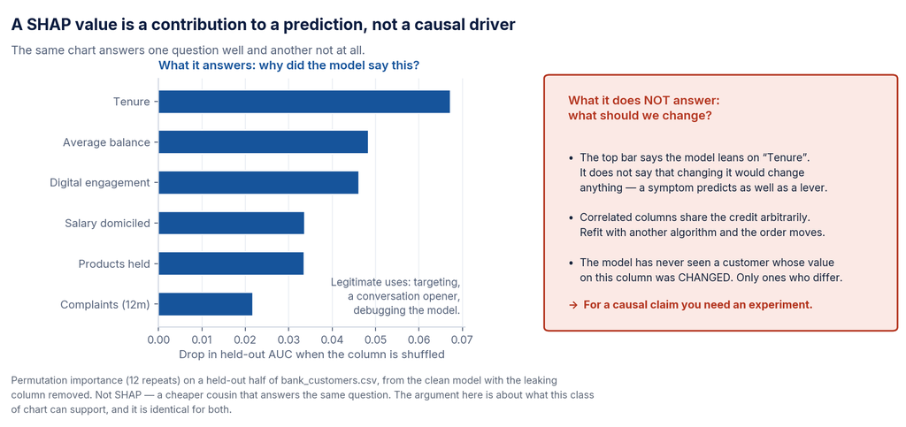

Left: six features ranked by drop in held-out AUC when shuffled. Right: a red panel listing three reasons the ranking does not tell you what to change.

## Say this out loud once

A SHAP value is a contribution to a prediction, not a causal driver.

It tells you what the model used. It does not tell you what the world does.

The distinction is easy to state and genuinely hard to hold on to under the pressure of a slide titled *“top drivers of churn”* — which is why it is worth saying aloud once, in a room, with other people hearing you.

## Two sentences from the same chart

**Not legitimate:**

Very little separates those two on the page. One is a statement about the model’s inputs; the other is a promise about the world’s mechanics, and only the second will be written into a business case with a budget and a target attached to it.

## Now in your sector · 5.1

Energy & extractives

'Wells with more maintenance spend have more downtime.' Age confounds both. 'Training hours cut incidents.' Who chose to train?

Data: energy_wells.csv

Pensions & public sector

'Employers we visited remit more.' Who got visited, and why? That is selection, not effect.

Data: pension_remittances.csv

Financial services

'App users churn less.'

Data: bank_customers.csv

Commercial & customer

'Spend drove sales.'

Data: marketing_spend.csv

## 5.2 · Experiments that settle arguments

10:45 — 11:45 · Design, power, and the thirty-second check

## An experiment is a device for ending an argument cheaply

Two executives take different views on whether a change works. Both have evidence, because both have looked at data genuinely consistent with their position. The disagreement runs two quarters, occupies four meetings, and is settled by whoever is more senior or more persistent.

The alternative is four weeks, half the users given the change and half not, and a number that both parties agreed in advance would settle the question.

That is not mainly a statistical device. It is a management device — a way of converting an argument that seniority would otherwise decide into one that a measurement decides.

## What randomisation actually buys

Not precision. **Comparability.**

Measuring what the treated group did is easy. The hard part is knowing what that same group would have done *without* the change, which you can never observe. So a second group stands in for it — and the entire question becomes whether the second group is a fair stand-in.

Let people choose, and it is not: the kind of person who opts in differs from the kind who does not. Assign at random, and the two groups end up alike on **everything** — the characteristics you measured, the ones you did not, and the ones nobody has ever thought to name.

## Five decisions, all made in advance

1. **The unit.** Users, customers, depots, branches, days. Randomise and analyse at the *same* level — assign by branch and you must analyse by branch.
2. **The primary metric**, written down in a sentence precise enough that somebody else could compute it, before you look at anything.
3. **The minimum effect worth detecting.** Not “any effect”, but the smallest improvement that would actually change the decision.
4. **The duration**, computed from decision 3 before the test starts.
5. **The guardrails.** Two or three metrics that must not deteriorate even if the primary one improves: complaints, refunds, margin, handling time.

`pwr.2p.test` → 35,501 per arm → at 4,000 eligible users a day, **eighteen days**. That is a date you can put in an email before anybody writes a line of code.

## Statistical power, in plain language

A test can fail in two directions. It can tell you there is an effect when there is not — the 5% significance level is what keeps that rare. It can also tell you there is **no** effect when there is one, simply because you did not gather enough observations for a real difference to stand out from ordinary week-to-week noise.

The chance of detecting a real effect of a given size is the **statistical power** of the test. The convention is to design for 80%: if the effect really is as large as you specified, you have an 80% chance of coming away able to say so.

Three things drive the number of observations you need, and each behaves the way common sense suggests. The rarer the event, the more you need. The smaller the difference you want to catch, the more you need — and halving the effect roughly **quadruples** the sample. The more certain you want to be of catching it, the more again.

## Three ways the calculation gets skipped

**“We’ll just run it and see.”** You will look at the numbers as they accumulate and stop when they look good. Every look is another chance for random fluctuation to cross the threshold. Fix the stopping rule in advance, or use a design built for repeated peeking.

**“We ran it for a week, it wasn’t significant, so it doesn’t work.”** The most expensive of the three, because it retires an idea that may well have been good. *Not significant* and *no effect* are different statements, and the distance between them is exactly the calculation nobody did.

**“We need 15,000 per arm and we only have 3,000.”** Not a failure — genuinely useful information, arriving *before* anybody spent the money.

## The check that comes before the result

```sql
SELECT arm, COUNT(*) AS users, AVG(converted) AS conversion_rate
FROM 'data/ab_test_checkout.csv' GROUP BY arm;
```

```
control     59,981    0.0442
treatment   55,989    0.0468
```

Treatment converts 5.7% better than control. Somebody in the meeting is already drafting the rollout email.

**Cover the right-hand column and look only at the arm sizes.** Under a 50/50 split, that gap is about **twelve standard deviations** away from what randomisation predicts.

## What a sample ratio mismatch means

The assignment mechanism did not deliver the split it promised, so something other than the coin decided who ended up where.

That is a **sample ratio mismatch**, usually shortened to **SRM**, and it is normally an instrumentation fault rather than a statistical one — a tagging bug that silently dropped a slice of one arm.

Once you have an SRM, nothing downstream is interpretable. The users who went missing are not a random subset, so the *composition* of the arm has changed, and no adjustment untangles that — you cannot condition on a population you no longer have.

The correct response is not to adjust and not to caveat. **Fix the instrumentation and re-run.**

## Positive on average. Negative where the money is.

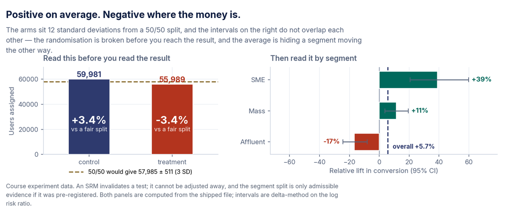

Left: two arm-size bars, control 3.4 percent above a fair split and treatment 3.4 percent below. Right: relative lift by segment with confidence intervals — SME and Mass positive, Affluent negative, none overlapping.

## Three segments named in advance, not twenty found afterwards

Look at the result for the two or three segments that matter commercially — and name them in the design document *before* the test starts.

The second half of that sentence is what separates the previous slide from a trap that looks almost identical. Slice a finished result twenty ways and you will find a “significant” segment by chance alone, because a 5% significance level means one false positive in twenty by construction.

Three segments named in advance is analysis, because you committed to being wrong about them. Twenty found afterwards and one reported is fishing, and it will not survive the next look.

## Experiments are not only a website thing

- **Depots and branches.** Randomise a new reorder policy to three of twelve depots and keep the other nine as controls. This is exactly what the availability capstone should propose.
- **Regions and territories.** Switch a pricing rule on in half the territories.
- **Time slices.** Alternate weeks, when the population genuinely cannot be split. Weaker, because seasonality moves between weeks, but real and much better than nothing.
- **Customer lists.** Hold out 10% of the retention call list — the single most valuable experiment most organisations are not running, because it is the only thing that tells you whether the calls work at all.
- **Staggered rollout.** You were going to roll out in phases anyway.

**Any phased rollout can be an experiment if you randomise the order rather than choosing it.** The cost is one conversation. The gain is knowing whether it worked.

## Now in your sector · 5.2

Energy & extractives

Randomise which sites get the new inspection checklist, or stagger a rollout (stepped wedge). For a gas distributor, A/B the billing reminder.

Pensions & public sector

Randomised reminder letters are the cheapest experiment a regulator or tax authority can run, and the pensions pack contains one. Run the thirty-second check before you read the result.

Data: pension_remittances.csv (reminder_arm)

Financial services

Collections SMS wording.

Data: ab_test_checkout.csv

Commercial & customer

A price or bundle test.

Data: ab_test_checkout.csv

## 5.3 · When you cannot randomise

11:45 — 12:30 · Weaker claims, stated honestly

## Before-and-after is not a causal design

*“We changed the reorder policy in November. Availability improved. The policy worked.”*

Consider what else happened between November and now. The season turned. The promotion calendar moved. A supplier’s performance changed. The exchange rate moved, which changed landed cost, which changed what got ordered. A competitor repriced. And a group of people started paying closer attention, because they knew a change was being watched.

A before-and-after comparison attributes every one of those to your change. It does not apportion them, and it does not flag them.

## Difference-in-differences, in words

The treated group’s before-and-after movement contains two things mixed together: the effect of the intervention, and the effect of everything else that happened over those weeks.

The comparison group’s movement contains only the second, because they had no intervention.

So if you are willing to believe that “everything else” affected both groups by the same amount, you can subtract the comparison group’s movement from the treated group’s, and what remains is the intervention.

Two differences, subtracted — hence **difference-in-differences**, often written DiD.

## Difference-in-differences, in numbers

An invented example, small enough to check by hand.

|  | Before | After | Change |
| --- | --- | --- | --- |
| **Treated depots** | 500 units/week | 380 | −120 |
| **Comparison depots** | 400 units/week | 440 | +40 |

Before-and-after would report the treated group’s fall of 120 as the effect.

Difference-in-differences says the comparison group’s rise of **+40** is what “everything else” was doing. Absent the intervention the treated group would have risen by 40 too, to **540**. So the estimated effect is 380 − 540 = **−160 units**.

The naive figure can be too small as easily as too large. It is not a conservative estimate; it is an arbitrary one.

## Parallel trends: the one assumption

Absent the intervention, the two groups would have carried on moving up and down together.

Not that they would sit at the same *level* — the treated depots can be larger or smaller than the rest. The requirement is that they would have moved **in step**, so that the comparison group’s path is a fair stand-in for the path the treated group would have taken.

If it fails, the number you compute is not an effect. It is the divergence the two groups were going to show anyway.

## Plot the pre-period, and put it on the page

If the two groups really do move together absent an intervention, they should have been moving together in the weeks *before* the intervention, when neither had received it.

Plot both series for the pre-period. You are not looking for two lines on top of each other; you are looking at whether the **slopes** match and whether the wobbles happen at the same time in both.

Putting that plot on the page beside the estimate is the strongest credibility move available in observational causal work. It costs four lines of code, and it shows the audience the assumption instead of asking them to take your word that it holds.

## Synthetic control, when there is no obvious comparison

Sometimes only one unit was treated — one depot, one region, one market — and no single other unit is a plausible comparison for it. The largest depot has no twin; the capital city behaves like nowhere else.

Build the comparison rather than looking for it.

Take a weighted blend of several untreated units, choosing the weights so the blend tracks the treated unit as closely as possible *in the period before the intervention*. If a mixture of several depots reproduces the treated depot’s history convincingly, that mixture is a defensible stand-in for what it would have done next.

The inference comes from **placebo runs**: repeat the whole procedure pretending, in turn, that each untreated unit was the treated one. Each of those gaps is pure noise, because nothing happened to that unit. If your real gap stands well outside them, you have found something.

## Interrupted time series, and its limits

Sometimes there is genuinely no comparison group at all — a regulation that applied to everybody on the same day, a national price change, a system switched over everywhere at once.

Build the counterfactual out of the history of the series itself.

Fit a model to the period before the intervention, forecast forward as though nothing had happened, and compare what actually occurred with that forecast and its interval. The gap is your estimate; the width of the forecast interval is your uncertainty, and it widens honestly as you look further past the intervention date.

This is the weakest of the four designs, for a reason that is easy to state and impossible to fix: it assumes the only thing that changed at the intervention date was the intervention.

## Rank your claims honestly

| Design | The claim you may make | The assumption |
| --- | --- | --- |
| Randomised experiment | *“X caused a Y% change, 95% CI [a, b]”* | Randomisation worked — check the SRM |
| Difference-in-differences | *“Consistent with X causing Y, assuming parallel trends, which held for N weeks”* | Parallel trends, in the scale you modelled |
| Synthetic control | *“A Y-point divergence from a matched comparison; placebos put it in the top k of m”* | The donor pool spans the treated unit |
| Interrupted time series | *“Outcomes were outside the 80% interval projected from history”* | Nothing else changed at that date |
| Before-and-after | **— not a causal design —** |  |

## The sentence that makes you credible

> *“This is not a randomised result. It is a difference-in-differences estimate against nine comparison depots, and it rests on the assumption that the two groups would have moved together. That assumption held for the twenty-six weeks before the change — here is the plot. My estimate is 3.1 points, interval 1.2 to 5.0. If we want a stronger claim, the next rollout phase should be randomised, which costs nothing extra.”*

## Now in your sector · 5.3

Energy & extractives

Difference-in-differences: a new maintenance strategy on one asset against a comparable asset. Synthetic control for a security programme.

Data: energy_production_daily.csv

Pensions & public sector

Policy evaluation: a new penalty regime or e-collection launch against sectors or states it did not touch. Plot the pre-period.

Data: pension_remittances.csv

Financial services

A branch-level rollout.

Data: bank_customers.csv

Commercial & customer

A regional launch.

Data: fmcg_sell_out.csv

## 5.4 · Governance you can actually run

13:15 — 14:00 · Not a compliance lecture

## Three questions an executive actually faces

1. May this data leave my network?
2. May this decision be made by a model?
3. Who is accountable when it is wrong?

This is a management briefing, not legal advice. Everything on the next slides is cited on the session page. Take the framework and the questions to your legal and data protection functions.

## The parts that bite

**NDPA 2023** — the primary law — plus the NDPC’s **GAID 2025**, issued 20 March 2025 and effective 19 September 2025, which supplies the operational detail.

- **Lawful basis** chosen and documented *before* you process. There are six, and *“we already had the data”* is not one of them.
- **Major importance:** >200 data subjects in six months, or finance / telecoms / health / oil and gas → register, appoint a DPO, file audit returns.
- **Audit** within 15 months of commencing, annually thereafter. GAID filing fees ₦100k–₦1m.
- **72 hours** to the NDPC for a high-risk breach.
- **Cross-border transfer** needs adequacy or an approved instrument.
- **Solely automated decisions** carry a right to human review.
- **Penalties:** up to ₦10m or 2% of gross revenue, whichever is higher.

## The obligation analytics teams most often miss

Where processing is likely to result in a **high risk** to the rights and freedoms of data subjects, the Act requires a **data protection impact assessment** before you start — and where the assessment concludes the processing would be high risk, you must consult the Commission before you process.

A DPIA is a written analysis done in advance: what you intend to do, why it is necessary, what could go wrong for the people whose data it is, and what you have put in place to reduce that.

A model card is good practice. A DPIA may be the law.

Systematic profiling of individuals sits squarely inside it — and a churn score, an attrition score and a credit propensity are all systematic profiling of individuals.

## The decision tree, run while the work is being scoped

**Does the work touch personal data?** If no — hosted tools are fine, and you still log what you did.

**Can it be anonymised or synthesised for this task?** If yes — anonymise, then hosted tools are fine, and document the method.

**Do we have an approved in-region or on-premises deployment?** If yes — use it, and record the lawful basis. If no — **a local model only, and nothing leaves the machine.**

Separately, and regardless of where it runs: **is a decision about a person made solely by the model?** If so, human review has to be in the loop, documented, with a route by which the person affected can challenge it.

## The question that applies to everything this week

Pasting customer text into a hosted assistant is very likely a cross-border transfer of personal data.

**The practical rule for Monday:** anonymised or synthetic data, or shapes and schemas rather than values, may go to a hosted assistant. Actual customer records go to a **local model**, an assessed in-region deployment, or nowhere.

## Wednesday’s model comes back

`commute_minutes` was one of the strongest predictors in the attrition model.

It is also a close proxy for where somebody lives, which is a proxy for income, and in many markets tracks ethnicity or religion as well. **No protected attribute appears anywhere in that file.**

Removing protected attributes does not remove discrimination. It removes your ability to measure it.

## The honest resolution for the HR case

Use the model to identify **teams and conditions** where attrition risk is elevated — commute burden, long waits for promotion, excessive span of control — and act on those systemically.

Do not attach a score to an individual employee’s file.

That trade costs less than people fear. Nearly all the value is in knowing *where* and *why* the risk concentrates, which is what tells you what to change. Almost all the exposure is in the individual score, which is the part that gets applied to a person, sits in a file, and is very hard to explain to them.

## The model card

One page per model, in language a non-specialist can read.

Purpose · **what it is NOT for** · the decision it feeds · training data and period · features, with *when each becomes available* · exclusions and why · performance overall · **performance on the worst segment** · known limitations · human review · monitoring · **retire by**.

The two lines everybody skips are **“Not for”** and **“Retire by”** — because models get reused for purposes they were never validated for, by people who were not in the room when they were built.

## Now in your sector · 5.4

Energy & extractives

Group policies plus the NDPA: employee, contractor and community data, and the transfer of operational data to headquarters abroad.

Pensions & public sector

Data controllers of major importance holding millions of records: DPIAs, retention, and AI use in public decisions. NITDA issued the NDPR in 2019; the NDPC now administers the Act and GAID.

Financial services

CBN rules alongside the NDPA; model cards for credit scoring; the right not to be subject to a purely automated decision.

Commercial & customer

Subscriber data, marketing consent, and the sector regulator alongside the NDPC.

## 5.5 · The operating model

14:00 — 14:30 · From pilot to portfolio

## Three shapes, and how each one fails

|  | **Centralised** | **Federated** | **Hub and spoke** |
| --- | --- | --- | --- |
| Analysts sit | In one team | In the business units | Both |
| Standards | Strong | Weak | Set centrally, applied locally |
| Business context | Weak | Strong | Adequate, if rotation happens |
| Speed | Slow — a queue | Fast | Fast for the spokes |
| Fails by | Becoming a ticket queue nobody uses | Five incompatible versions of “revenue” | The hub becoming a policeman |

**Most organisations should be hub and spoke**, and most say they are. The test is not the org chart. It is whether the hub owns the definitions, the pipeline standards and the model register — and whether anybody in the business units can read a query.

## Hire the analytics engineer first

The instinct is to hire a data scientist, and it is understandable — it is the role with the clearest identity and the most obvious connection to the thing you want.

What follows is specific enough to describe. A capable person joins an organisation with no reliable tables, spends months assembling extracts by hand, discovers they disagree with the finance system, spends more months reconciling, builds something impressive on a dataset only they can reproduce, and leaves at eighteen months.

**1.** Analytics engineer — trustworthy tables · **2.** Business analyst embedded in a function · **3.** Data scientist · **4.** Platform, when scale genuinely demands it

And the role nobody budgets for: **somebody whose job is to make the output get used.**

## Three mechanisms that turn pilots into a portfolio

**A model register with a retirement date.** One row per model in production: what it is, who owns it, what decision it feeds, when it was last validated, and the date by which it must be revalidated or switched off.

**A decision log.** What was decided, on what evidence, what was expected to happen, and — the column everybody omits — **what actually happened.** Six months of an honest one is the most valuable management asset the function will ever produce.

**A quarterly review that kills things.** A portfolio that has never stopped anything is not being managed; it is being accumulated.

## The 90-day plan that goes in your capstone

**Days 1–14 · Prove the pipeline.** Raw extract to tested table, running, with the quality contract. No new spend, no new headcount, no permissions. Deliverable: the pipeline runs and one number is defensible.

**Days 15–45 · Prove the decision changes.** One person, one recurring decision, using the output. Not a rollout — one person. Deliverable: they used it, and you can say what they did differently.

**Days 46–90 · Prove the value, with a comparison.** The randomised or quasi-experimental design from this morning. Deliverable: a number with an interval, and an honest statement of what design produced it.

The order is deliberate: the plumbing before the decision, and the decision before the value. A plan that tries to prove value first has to assume the other two and will be attacked on both.

## What will actually stop you

The person whose judgement your initiative displaces.

The depot manager who has ordered by feel for eleven years and is usually right. The relationship manager who knows which customers to call. Each is experienced, respected, and correct often enough to have a genuine case.

**Make them the author.** Bring the model as a draft rather than as a decision, and ask what it gets wrong.

**Show the override log.** Let them override, log the reason, and measure which overrides improved the outcome. Roughly half of them do, which says the model needs the human.

**Change what they are measured on**, rather than what they are told to do.

## Rehearsal

14:30 — 15:15

Twelve minutes with a Sceptic from a table you have not worked with.

**Their instruction:** find the question the presenter is least prepared for, and ask it twice.

**Their second instruction:** exactly one sentence of feedback. Not a list. The one thing that, if fixed, most improves the defence.

## The five questions, published on Monday

1. What is the grain of this table?
2. Would you have known this at the time you needed to act?
3. Is that real or nominal?
4. How would you know if you were wrong?
5. Who loses if this works?

And the sixth: **which of these numbers did the assistant produce, and which did you check?**

## Answering a question you cannot answer

It will happen. The panel is drawn from three disciplines, so at least one of them will ask about something outside where you spent your week.

1. **Say plainly that you do not know.** No preamble and no apology.
2. **Say what you do know that bears on it** — the adjacent fact, the related check you did run, the boundary of what you established.
3. **Say how you would find out**, concretely enough that somebody could start: which table, which comparison, roughly how long.
4. **Say what would change if the answer went either way.**

The fourth step is the one almost nobody does, and it is the one that turns the exchange around, because it shows you know how much rests on the open question.

## Now in your sector · 5.5

Energy & extractives

A centre of excellence at global HQ, or analysts embedded in the asset? Operators that took over divested assets get to design the function from scratch.

Pensions & public sector

An analytics unit inside a regulator: who owns supervision data, ICT or the departments? What does procurement allow?

Financial services

Hub-and-spoke across subsidiaries.

Commercial & customer

In a small firm: one analytics engineer before any data scientist.

## Capstone defence

15:30 — 17:00 · three parallel rooms

Five minutes. Four minutes of questions. No slides. **Everybody presents.**

Business impact **40%** · analytical rigour **30%** · communication **20%** · feasibility and governance **10%**.

A capstone cannot pass on rigour alone. That weighting is deliberate, and it is roughly the distribution of value in the world outside this room.

## The five minutes, minute by minute

**0:00–0:30 — The number and the action.** One sentence containing a figure, a verb and a date. Then stop for two seconds and let it land.

**0:30–1:15 — The confidence.** The interval, the single assumption that drives its width, and what it would cost to narrow it.

**1:15–1:45 — The ask.** Specific, addressed and dated — including *“nothing, this is for information”* if that is the truth.

**1:45–3:00 — The evidence.** Where the data came from, its grain, what you found wrong with it and what you did about it.

**3:00–3:45 — The evidence standard.** What kind of claim you are making, and what a stronger one would need. Concede this before you are asked.

**3:45–4:15 — Governance and the 90 days.** **4:15–5:00 — What happens if you are wrong.**

## 17:00 · The two envelopes

Monday’s number, with its interval. Today’s number, with its interval.

For most people the number moved a little and **the interval got wider.**

That is not a failure of the week. It is the week working. You now know more about what you do not know, which is the condition for every good decision you will make with data from here.

Then the failure logbook, consolidated, read aloud, and sent to everybody.